## Data Analysis

This document documents the workflow for data exploration, model building, and model selection, ensuring that each step of the analysis is transparent.

Load the libraries

```r
if(!require(tidyverse)){install.packages("tidyverse")}
if(!require(mgcv)){install.packages("mgcv")}
if(!require(GGally)){install.packages("GGally")}
if(!require(gratia)){install.packages("gratia")}
if(!require(flextable)){install.packages("flextable")}
```

### Data

#### Load the database

Load the database

```r
dat <- read.csv("Data/data.csv",
                stringsAsFactors = T)
```

Glimpse the database

```r
glimpse(dat)
```

```
## Rows: 474
## Columns: 15
## $ name           <fct> fisher_1, fisher_1, fisher_1, fisher_1, fisher_1, fishe…
## $ age            <int> 57, 57, 57, 57, 57, 57, 42, 42, 42, 42, 42, 42, 42, 42,…
## $ local          <fct> Rio do Fogo, Rio do Fogo, Rio do Fogo, Rio do Fogo, Rio…
## $ fishing_exp    <int> 30, 30, 30, 30, 30, 30, 25, 25, 25, 25, 25, 25, 25, 25,…
## $ octopus_exp    <int> 17, 17, 17, 17, 17, 17, 23, 23, 23, 23, 23, 23, 23, 23,…
## $ boat_year      <int> 2008, 2008, 2008, 2008, 2008, 2008, 2017, 2017, 2017, 2…
## $ environment    <fct> Shallow Sedimentary Reefs (n=41), Shallow Sedimentary R…
## $ year           <int> 2008, 2018, 2008, 2024, 2008, 2024, 2002, 2017, 2024, 2…
## $ period         <fct> Before, After, Before, After, Before, After, Before, Af…
## $ catch          <dbl> 20.0, 11.0, 17.5, 50.0, 20.0, 60.0, 40.0, 35.0, 30.0, 3…
## $ n_divers       <int> 3, 2, 3, 3, 3, 3, 2, 2, 2, 2, 2, 2, 2, 2, 2, 3, 3, 3, 3…
## $ time_fishing_h <dbl> 4.0, 1.5, 4.0, 5.0, 4.0, 4.0, 5.0, 5.0, 10.0, 6.0, 5.0,…
## $ pots           <fct> No, No, No, Yes, No, Yes, No, No, No, No, Yes, Yes, No,…
## $ type_boat      <fct> sailboat, engine_boat, sailboat, engine_boat, sailboat,…
## $ seascape       <fct> Unmodified, Unmodified, Modified, Modified, Modified, M…
```

#### Variables description

| Variable | Description |
| --- | --- |
| `name` | Fisher’s name |
| `age` | Fisher’s age |
| `date` | Survey date |
| `local` | Surveyed beaches |
| `fishing_exp` | Fishing experience |
| `octopus_exp` | Octopus fishing experience |
| `boat_year` | Year of the first boat |
| `environment` | Different fishing environments |
| `dives` | Number of dives per day |
| `year` | Year of observation |
| `period` | Before or After pots implementation |
| `catch` | Octopus catch on a typical fishing day |
| `n_fishers` | Number of fishers on the boat |
| `n_divers` | Number of divers on the boat |
| `time_fishing_h` | Duration of the fishing trip in hours (excluding travel time) |
| `pots` | Presence or absence of pots |

#### Data exploration

Reorder factor levels. Categorical variables were reordered to define the desired reference levels before model fitting. This ensures that model coefficients and contrasts are estimated relative to the intended baseline category, facilitating the interpretation of the results.

```r
# ------------------------------- Ordering variables
# Environment
dat <- dat %>%
  mutate(environment = recode(environment,
                              "Flat Biogenic Plateaus (n=67)" = "Biogenic Plateaus (n=67)",
                              "Gravel Beds (n=57)" = "Gravel Beds (n=57)",
                              "Outer Reef Slope (n=30)" = "Deep Reef (n=30)",
                              "Shallow Sedimentary Reefs (n=41)" = "Shallow Reef (n=41)"))

dat$environment <- factor(dat$environment,
                          levels = c("Shallow Reef (n=41)",
                                     "Deep Reef (n=30)",
                                     "Gravel Beds (n=57)",
                                     "Biogenic Plateaus (n=67)"))

# Period
dat$period <- factor(dat$period,
                     levels = c ("Before",
                                 "After"))
# Type Boat
dat$type_boat <- factor(dat$type_boat,
                        levels = c ("sailboat",
                                    "engine_boat"))
```

Here is the calculation for our response variable: Catch Per Unit Effort (cpue). It is computed as the ratio of the catch reported by the fisherman to the product of the number of divers on each vessel and the fishing hour (not including travel time). Next, we will check it.

```r
dat$cpue <- (dat$catch/(dat$n_divers*dat$time_fishing_h))
```

We begin by exploring the response variable (CPUE) to assess its distribution and identify potential patterns before model fitting.

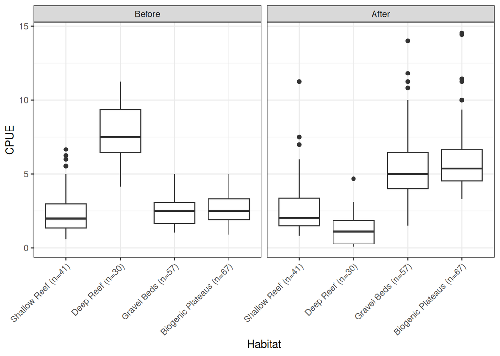

```r
ggplot(dat, aes(x = environment, y = cpue))+
  geom_boxplot()+
  facet_wrap(~ period) +
  labs(x = "Habitat", y = "CPUE")+
  theme_bw() +
  theme(axis.text.x = element_text(angle = 45, hjust=1))
```

Dotplots are useful to identify outliers and homogeneity

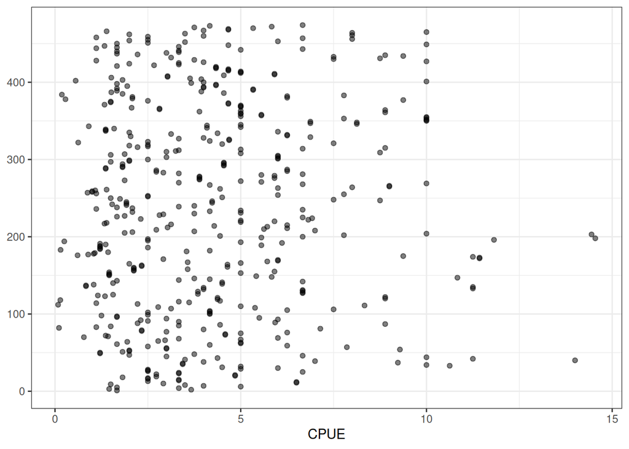

```r
dat |>
  mutate(row_id = row_number()) |>
  ggplot(aes(x= cpue, y = row_id))+
  geom_point(alpha = 0.5)+
  labs(x = "CPUE", y = NULL)+
  theme_bw()
```

The extreme values are not outliers. But we can observe some values near to zero.

Coplots help visualize how the response variable is related to the explanatory variables.

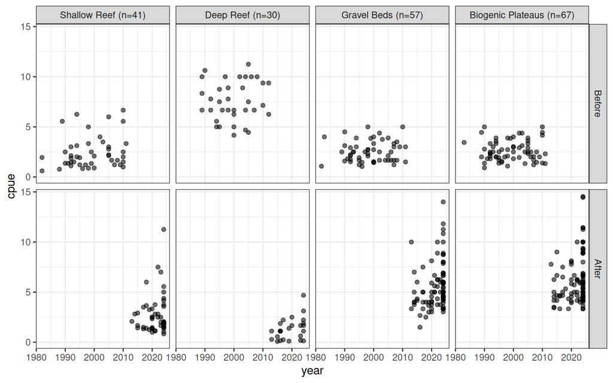

```r
ggplot2::ggplot(dat, aes(x = year, y = cpue))+
  geom_point(aes(alpha = 0.3))+
  facet_grid(period ~ environment)+
  theme_bw()+
  theme(legend.position = "none")
```

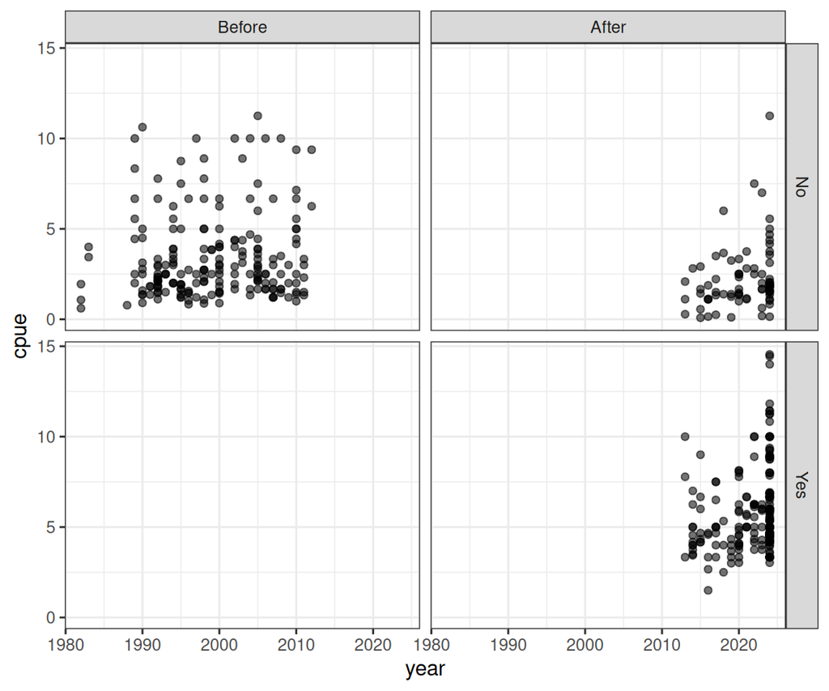

```r
ggplot2::ggplot(dat, aes(x = year, y = cpue))+
  geom_point(aes(alpha = 0.3))+
  facet_grid(pots ~ period)+
  theme_bw()+
  theme(legend.position = "none")
```

This plot makes clear the relationship between the variables `period` and `pots`, given that pots are only present in the `after` period. I will remove the `pots` variable from the model, given that `before` and `after` refer to the effect of the pots.

Next, we inspect the CPUE distribution using a histogram to evaluate its shape and identify potential skewness or outliers.

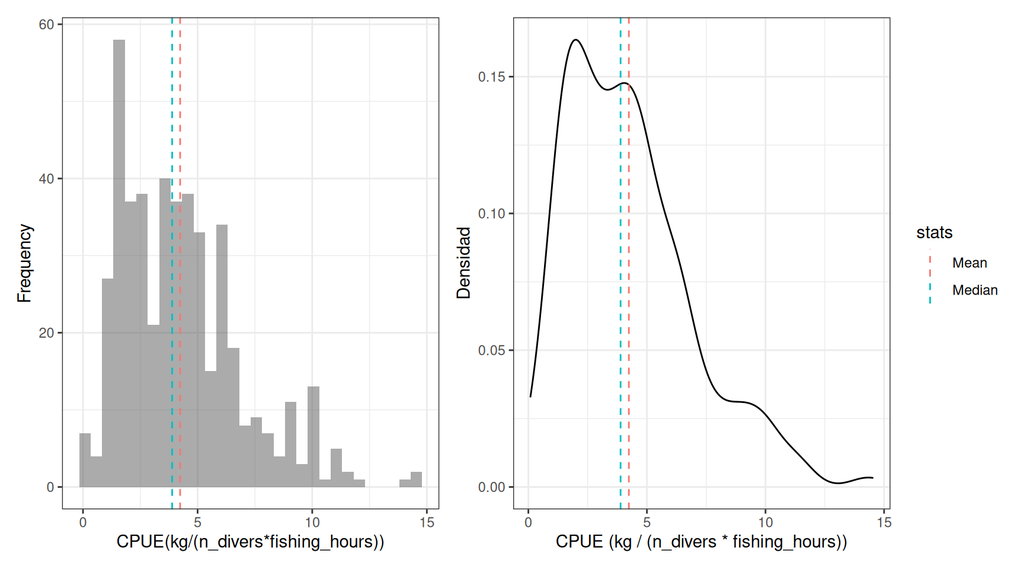

```r
par(mfrow = c (1,2))
ggplot(dat,aes(x = cpue))+
  geom_histogram(bins = 30,
                 alpha = 0.5)+
  labs(x = "CPUE(kg/(n_divers*fishing_hours))",
       y = "Frequency")+
  geom_vline(data = sumstat,
             aes(xintercept = value,
                 col = stats),
             linetype = "dashed")+
  theme_bw() +
  theme(legend.position="none") +
  ggplot(dat, aes(x = cpue)) +
  geom_density() +
  labs(x = "CPUE (kg / (n_divers * fishing_hours))",
       y = "Densidad") +
  geom_vline(data = sumstat,
             aes(xintercept = value,
                 col = stats),
             linetype = "dashed") +
  theme_bw()
```

Although there are values very close to zero, there are no zero or negative values. We can also observe that the data distribution is right-skewed, with mean values exceeding median values. Therefore, for the modeling process, we can decide to use the Tweedie distribution.

```r
summary(dat$cpue)
```

```
##     Min.  1st Qu.   Median     Mean  3rd Qu.     Max.
##  0.08333  2.08333  3.88889  4.23815  5.80357 14.54545
```

### Models

Model 1 - Full Model

```r
mod1 <- mgcv::gam(cpue ~ environment+
                    type_boat+
                    s(fishing_exp)+
                    s(octopus_exp)+
                    s(year, k = 5, by = environment) +
                    s(name, bs = "re"),
                  family = tw(link = "log"),
                  data = dat,
                  method = "REML")
```

```r
summary(mod1)
```

```
##
## Family: Tweedie(p=1.257)
## Link function: log
##
## Formula:
## cpue ~ environment + type_boat + s(fishing_exp) + s(octopus_exp) +
##     s(year, k = 5, by = environment) + s(name, bs = "re")
##
## Parametric coefficients:
##                                     Estimate Std. Error t value Pr(>|t|)
## (Intercept)                          0.82150    0.08727   9.413  < 2e-16 ***
## environmentDeep Reef (n=30)          0.19911    0.07840   2.540   0.0115 *
## environmentGravel Beds (n=57)        0.41729    0.05169   8.072 8.13e-15 ***
## environmentBiogenic Plateaus (n=67)  0.45195    0.04944   9.141  < 2e-16 ***
## type_boatengine_boat                 0.19808    0.10396   1.905   0.0574 .
## ---
## Signif. codes:  0 '***' 0.001 '**' 0.01 '*' 0.05 '.' 0.1 ' ' 1
##
## Approximate significance of smooth terms:
##                                                edf Ref.df      F p-value
## s(fishing_exp)                               1.705  1.784  0.841   0.468
## s(octopus_exp)                               1.000  1.000  0.105   0.746
## s(year):environmentShallow Reef (n=41)       1.001  1.001  0.135   0.714
## s(year):environmentDeep Reef (n=30)          3.842  3.978 34.790 < 2e-16 ***
## s(year):environmentGravel Beds (n=57)        2.285  2.751 14.250 4.6e-07 ***
## s(year):environmentBiogenic Plateaus (n=67)  2.389  2.848 15.800 < 2e-16 ***
## s(name)                                     56.149 69.000  5.151 < 2e-16 ***
## ---
## Signif. codes:  0 '***' 0.001 '**' 0.01 '*' 0.05 '.' 0.1 ' ' 1
##
## R-sq.(adj) =  0.725   Deviance explained = 76.6%
## -REML = 855.81  Scale est. = 0.29851   n = 474
```

The effect of boat type was not statistically significant and was therefore excluded.

Model 2 - The `type_boat` variable was removed.

```r
mod2 <- mgcv::gam(cpue ~ environment +
                    s(fishing_exp)+
                    s(octopus_exp)+
                    s(year, k = 5, by = environment) +
                    s(name, bs = "re"),
                  family = tw(link = "log"),
                  data = dat,
                  method = "REML")
```

```r
summary(mod2)
```

```
##
## Family: Tweedie(p=1.253)
## Link function: log
##
## Formula:
## cpue ~ environment + s(fishing_exp) + s(octopus_exp) + s(year,
##     k = 5, by = environment) + s(name, bs = "re")
##
## Parametric coefficients:
##                                     Estimate Std. Error t value Pr(>|t|)
## (Intercept)                          0.95206    0.05385  17.679  < 2e-16 ***
## environmentDeep Reef (n=30)          0.19497    0.07847   2.485   0.0134 *
## environmentGravel Beds (n=57)        0.41035    0.05157   7.957 1.83e-14 ***
## environmentBiogenic Plateaus (n=67)  0.44496    0.04935   9.017  < 2e-16 ***
## ---
## Signif. codes:  0 '***' 0.001 '**' 0.01 '*' 0.05 '.' 0.1 ' ' 1
##
## Approximate significance of smooth terms:
##                                                edf Ref.df      F p-value
## s(fishing_exp)                               1.740  1.820  0.894 0.44026
## s(octopus_exp)                               1.000  1.000  0.116 0.73375
## s(year):environmentShallow Reef (n=41)       1.001  1.001  6.942 0.00873 **
## s(year):environmentDeep Reef (n=30)          3.808  3.971 56.142 < 2e-16 ***
## s(year):environmentGravel Beds (n=57)        2.472  2.973 53.704 < 2e-16 ***
## s(year):environmentBiogenic Plateaus (n=67)  3.023  3.494 62.075 < 2e-16 ***
## s(name)                                     56.201 69.000  5.199 < 2e-16 ***
## ---
## Signif. codes:  0 '***' 0.001 '**' 0.01 '*' 0.05 '.' 0.1 ' ' 1
##
## R-sq.(adj) =  0.727   Deviance explained = 76.6%
## -REML = 855.97  Scale est. = 0.29996   n = 474
```

The effect of `octopus fishing experience` experience was not statistically significant and was therefore excluded.

Model 3 - The `octopus fishing` variable was removed.

```r
mod3 <- mgcv::gam(cpue ~ environment +
                    s(fishing_exp)+
                    s(year, k = 5, by = environment) +
                    s(name, bs = "re"),
                  family = tw(link = "log"),
                  data = dat,
                  method = "REML")
```

```r
summary(mod3)
```

```
##
## Family: Tweedie(p=1.253)
## Link function: log
##
## Formula:
## cpue ~ environment + s(fishing_exp) + s(year, k = 5, by = environment) +
##     s(name, bs = "re")
##
## Parametric coefficients:
##                                     Estimate Std. Error t value Pr(>|t|)
## (Intercept)                          0.95300    0.05355  17.798  < 2e-16 ***
## environmentDeep Reef (n=30)          0.19447    0.07844   2.479   0.0136 *
## environmentGravel Beds (n=57)        0.41022    0.05156   7.957 1.82e-14 ***
## environmentBiogenic Plateaus (n=67)  0.44506    0.04934   9.021  < 2e-16 ***
## ---
## Signif. codes:  0 '***' 0.001 '**' 0.01 '*' 0.05 '.' 0.1 ' ' 1
##
## Approximate significance of smooth terms:
##                                                edf Ref.df      F p-value
## s(fishing_exp)                               1.927  2.018  0.896 0.38291
## s(year):environmentShallow Reef (n=41)       1.001  1.002  7.020 0.00836 **
## s(year):environmentDeep Reef (n=30)          3.808  3.970 56.153 < 2e-16 ***
## s(year):environmentGravel Beds (n=57)        2.468  2.969 53.869 < 2e-16 ***
## s(year):environmentBiogenic Plateaus (n=67)  3.022  3.492 62.165 < 2e-16 ***
## s(name)                                     56.659 70.000  5.103 < 2e-16 ***
## ---
## Signif. codes:  0 '***' 0.001 '**' 0.01 '*' 0.05 '.' 0.1 ' ' 1
##
## R-sq.(adj) =  0.727   Deviance explained = 76.5%
## -REML = 854.26  Scale est. = 0.30005   n = 474
```

The effect of `fishing experience` experience was not statistically significant and was therefore excluded.

Model 4 - The `fishing_exp` variable was removed.

```r
mod4 <- mgcv::gam(cpue ~ environment+
                    s(year, k = 5, by = environment) +
                    s(name, bs = "re"),
                  family = tw(link = "log"),
                  data = dat,
                  method = "REML")
```

After removing the non-significant variables, all remaining predictors showed statistically significant effects.

Finally, model selection was based on the Akaike Information Criterion (AIC), with the model exhibiting the lowest AIC considered the best-supported model.

```r
AIC(mod1, mod2, mod3, mod4)
```

```
##            df      AIC
## mod1 78.79117 1612.290
## mod2 78.96612 1612.805
## mod3 78.23087 1611.650
## mod4 77.16997 1609.678
```

### Check Model

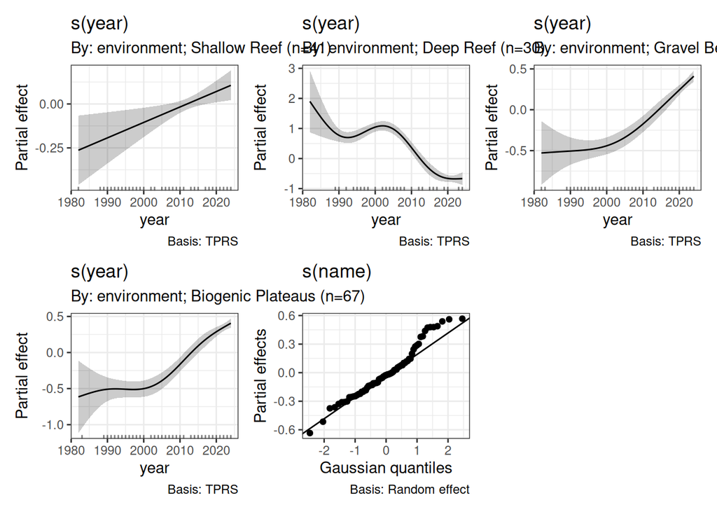

```r
gratia::draw(mod4) &
  theme_bw()
```

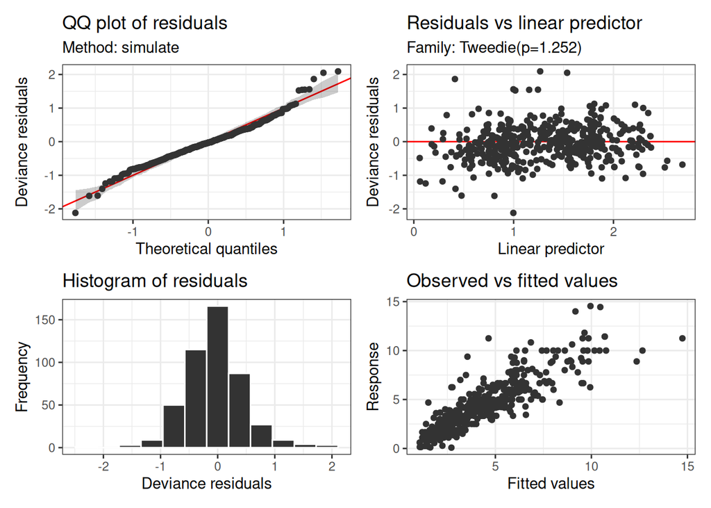

```r
gratia::appraise(mod4,
                 method = 'simulate',
                 seed = 123) &
  theme_bw()
```

```r
mgcv::k.check(mod4)
```

```
##                                             k'       edf   k-index p-value
## s(year):environmentShallow Reef (n=41)       4  1.000557 0.8865217  0.0100
## s(year):environmentDeep Reef (n=30)          4  3.808825 0.8865217  0.0075
## s(year):environmentGravel Beds (n=57)        4  2.477068 0.8865217  0.0025
## s(year):environmentBiogenic Plateaus (n=67)  4  3.041353 0.8865217  0.0025
## s(name)                                     72 58.399037        NA      NA
```

### Plot temporal change

```r
p_obj <- plot(mod4, residuals = TRUE)
```

```r
p_sr <- p_obj[[1]]
p_dr <- p_obj[[2]]
p_gb <- p_obj[[3]]
p_bp <- p_obj[[4]]
```

```r
# Shallow reefs
sm_sr <- as.data.frame(p_sr[c("x", "se", "fit")])
data_sr <- as.data.frame(p_sr[c("raw", "p.resid")])
# Deep reefs
sm_dr <- as.data.frame(p_dr[c("x", "se", "fit")])
data_dr <- as.data.frame(p_dr[c("raw", "p.resid")])
# Gravel Beds
sm_gb <- as.data.frame(p_gb[c("x", "se", "fit")])
data_gb <- as.data.frame(p_gb[c("raw", "p.resid")])
# Biogenic Plateaus
sm_bp <- as.data.frame(p_bp[c("x", "se", "fit")])
data_bp <- as.data.frame(p_bp[c("raw", "p.resid")])
```

```r
## plot Shallow Reefs
plot_sr <- ggplot(sm_sr, aes(x = x, y = fit)) +
  geom_rug(data = data_sr, mapping = aes(x = raw, y = NULL),
           sides = "b") +
  geom_ribbon(aes(ymin = fit - se, ymax = fit + se, y = NULL),
              alpha = 0.3) +
  geom_line() +
  geom_vline(xintercept = 2013, linetype = "dashed", colour = "gray") +
  labs(x = "", y = " ") +
  theme_classic()+
  ggtitle("Shallow Reefs")


## plot Deep Reefs
plot_dr <- ggplot(sm_dr, aes(x = x, y = fit)) +
  geom_rug(data = data_dr, mapping = aes(x = raw, y = NULL),
           sides = "b") +
  geom_ribbon(aes(ymin = fit - se, ymax = fit + se, y = NULL),
              alpha = 0.3) +
  geom_line() +
  geom_vline(xintercept = 2013, linetype = "dashed", colour = "gray") +
  labs(x = "", y = "") +
  theme_classic()+
  ggtitle("Deep Reefs")

## plot Gravel Beds
plot_gb <- ggplot(sm_gb, aes(x = x, y = fit)) +
  geom_rug(data = data_gb, mapping = aes(x = raw, y = NULL),
           sides = "b") +
  geom_ribbon(aes(ymin = fit - se, ymax = fit + se, y = NULL),
              alpha = 0.3,
              fill = "cornflowerblue") +
  geom_line(colour = "cornflowerblue") +
  geom_vline(xintercept = 2013, linetype = "dashed", colour = "gray") +
  labs(x = "Year", y = "") +
  theme_classic()+
  ggtitle("Gravel Beds")

## plot Biogenic Plateus
plot_bp <- ggplot(sm_bp, aes(x = x, y = fit)) +
  geom_rug(data = data_bp, mapping = aes(x = raw, y = NULL),
           sides = "b") +
  geom_ribbon(aes(ymin = fit - se, ymax = fit + se, y = NULL),
              alpha = 0.3,
              fill = "cornflowerblue") +
  geom_line(colour = "cornflowerblue") +
  geom_vline(xintercept = 2013, linetype = "dashed", colour = "gray") +
  labs(x = "Year", y = "") +
  theme_classic()+
  ggtitle("Biogenic Plateus")
```

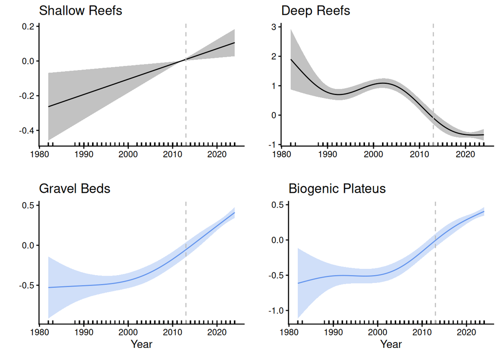

```r
plot <- gridExtra::grid.arrange(plot_sr, plot_dr, plot_gb, plot_bp, ncol=2, nrow=2)
```

```r
plot
```